# Tutorial 6: Figure 4: human model simulation

Wei-Chun Chou

June, 2020

# Introduction

# Prerequisites

Before running your model, you should set up your working directory, compile the PBPK model, install all required packages and input needed datasets. The model file and datasets can be found in the additional files.

## Setting up your working directory

The working directory has to be changed to the **PlotCode** folder. You can use two ways to change your working directory as follow:

1. Use RStudio: use the menu to change your working directory under **Session > Set Working Directory > Choose Directory**.
2. Use R function: use the R function `setwd()` to change the path to your working directory.

## Loading required R packages

The list of R packages should be installed prior to the simulation. If you have not installed these packages (listed below), please install these packages to your Rstudio using the R function `require (" ")` and then use `library` open it.

```r
##  Loading requried R packages
library(mrgsolve)    ## R-package for Loading mrgsolve code
library(magrittr)    ## R-package for the pipe, %>%
library(dplyr)       ## R-package for transform and summarize tabular data
library(tidyverse)   ## R-package for transform and summarize tabular data
library(ggplot2)     ## R-package for GGplot
library(FME)         ## R-package for model fitting
library(minpack.lm)  ## R-package for model fitting
library(gridExtra)   ## R-package for function "grid.arrange"
```

## Read mrgsolve-based PBPK Model R file

The pre-pregnant, gestational and lactational PBPK model in humans were written in `HMod.R` file. Before compiling the model, please conduct/call this file using R function `source`.

```r
## Input mrgsolve-based PBPK Model
source (file = "HMod.R")  ## input the human model for nonpregnnat, geatation and lactation
```

## Compile mrgsolve-based PBPK Model

Read the code and build these mrgsolve-based PBPK models. You should make sure all models are built correctly.

```r
## Build mrgsolve-based PBPK Model
PreGmod_H <- mcode ("PreGHumanPBPK.code", PreGHumanPBPK.code)
```

```
## Building PreGHumanPBPK_code ... done.
```

```r
Gmod_H    <- mcode ("GHumanPBPK.code", GHumanPBPK.code)
```

```
## Building GHumanPBPK_code ... done.
```

```r
Lmod_H    <- mcode ("LHumanPBPK.code", LHumanPBPK.code)
```

```
## Building LHumanPBPK_code ... done.
```

## Loading datasets

In this step, you need to input the .csv file to the Rstudio. The function `read.csv` can be used to read the csv files into R

```r
HDat <- read.csv(file = "Data_H.csv")
```

## Loading Fit results from rds files to obtain final parameter values

```r
GFit_H <- readRDS(file = "GFit_H.rds")
LFit_H <- readRDS(file = "LFit_H.rds")
```

## Input prediction function (one prediction function represents one exposure scenario to be run using the PBPK model)

```r
source (file = "Pred_H.R")
```

# Define the prediction function

The prediction functions are defined here to predict the time-varying profiles of PFOS in maternal plasma, fetal/neonatal plasma and milk during gestation and lactation.

- PBPK_H_G: Prediction function for the simulation of gestational model.
- PBPK_H_L: Prediction function for the simulation of lactational model.

```r
## Define the prediction function from pre-pregnant to gestational exposure
PBPK_H_G <- function(pars, DOSE, pred = FALSE) {

  ## Extract the PFOS concentration in all tissues in non-pregnant women
  Init <- Pred.preG (DOSE) %>% filter (row_number()== n()) %>%
  select(-c("Plasma", "Liver", "Kidney"))

  ## Get out of log domain
  Gpars_H <- lapply(pars, exp)  ## Return a list of exp (parametrs)

  ## Exposure scenario for gestational exposure
  GBW          = 67                     ## Body weight during gestation
  tinterval    = 24                     ## Time interval;
  GTDOSE       = 7*41                   ## Total dosing/Dose times;
  GDOSE        = DOSE                   ## Input oral dose
  GDOSEoral    = GDOSE*GBW              ## Amount of oral dose

  # To create a data set of 1 subject receiving DOSE every 24 hours
  Gex.oral <- ev (ID   = 1,             ## One individual
                  time = 0,             ## Dosing start time (GA0)
                  amt  = GDOSEoral,     ## Amount of dose
                  ii   = tinterval,     ## Time interval
                  addl = GTDOSE - 1,    ## Additional dosing
                  cmt  = "AST", ## The dosing compartment: AST
                  replicate = FALSE)    ## No replicate

  ## Simulation time from GA0 to GA 41 (weeks) + 1 day (simulate 41 weeks, but obtain data at GA40 below)
  Gtsamp  = tgrid(0, tinterval*(GTDOSE - 1) + 24*1, 24)

  ## Simulation of exposure scenario
  Gout <-
    Gmod_H %>% ## Gestational PBPK model
    init(APlas_free = Init$APlas_free, ## Input the initial concentrations
         APTC = Init$APTC,
         AFil = Init$AFil, AKb = Init$AKb, ARest = Init$ARest,
         AL = Init$AL, AM = Init$AM, AF = Init$AF,
         A_baso = Init$A_baso,
         A_apical = Init$A_apical, Adif = Init$Adif,
         Aefflux = Init$Aefflux) %>%
    param (Gpars_H) %>% ## Update the parameter list with Gpars
    update(atol = 1E-6,  maxsteps = 500000) %>%  ## Atol: Absolute tolerance parameter; maxsteps:maximum number of steps
    mrgsim_d (data = Gex.oral, tgrid = Gtsamp)

## Extract the "Time", "CPlas", "CL" , "CPlas_P", "CPla" and "Curine" from Gout
Goutdf = cbind.data.frame(Time = Gout$time/(24*7),
           CPlas    = Gout$Plasma*1000,
           CL       = Gout$Liver*1000,
           CPlas_pup  = Gout$CordB*1000,
           CPla     = Gout$Placenta*1000)

if (pred) return (Goutdf) # if pred = TRUE, output the Goutdf

Init_G <-
Gout %>% filter (time == 40*24*7) ## Extract the concentration at GA40
return (Init_G)
}


## Define the prediction function for lactation period
PBPK_H_L <- function(Gpars_H, Lpars_H, DOSE) {

## Extract the initial concentration from gestational model
Init_G <- PBPK_H_G (Gpars_H, DOSE)

## Get out of log domain
Lpars_H <- exp(Lpars_H) ## Return a list of exp (parametrs)

## Exposure scenario for lactational exposure; through postnatal weeks (PNW)0 - PNW41
  LBW          = 67 ## human body weight before lactation
  tinterval    = 24 ## Time interval;
  LTDOSE       = 41*7 ## Total dosing/Dose times;
  LDOSE        = DOSE   ## Repeat oral dose  (mg/kg/day);
  LDOSEoral    = LDOSE*LBW  ## Amount of oral dose (mg)


## To create a data set of 1 subject receiving DOSE every 24 hours
  Lex.oral <- ev (ID   = 1,             ## One individual
                  amt  = LDOSEoral,     ## Amount of dose
                  ii   = tinterval,     ## Time interval
                  addl = LTDOSE - 1,    ## Additional dosing
                  cmt  = "AST", ## The compartment: AST Stomach
                  replicate = FALSE)    ## No replicate

  ## Simulation time from PNW0 to PNW41 plus 7 days without dosing
  Ltsamp       = tgrid(0, tinterval*(LTDOSE - 1) + 24*7, 24)


  Lout <- Lmod_H %>% # Lactational model
  init(APlas_free =  Init_G$APlas_free, # Input the initial concentration
       APTC =  Init_G$APTC,
       AFil =  Init_G$AFil, AKb =     Init_G$AKb,
       ARest =  Init_G$ARest, AL =  Init_G$AL,
       AM =  Init_G$AM, AF =  Init_G$AF,
       A_baso =  Init_G$A_baso, A_apical = Init_G$A_apical,
       Adif =  Init_G$Adif,
       Aefflux =  Init_G$Aefflux,
       APlas_free_neo =  Init_G$APlas_Fet_free,
       AL_neo =  Init_G$AL_Fet, ARest_neo =  Init_G$ARest_Fet) %>%
    param (Lpars_H) %>% # Update the parameter list with pars
    update(atol = 1E-6, maxsteps = 500000) %>%
    mrgsim_d (data = Lex.oral, tgrid = Ltsamp)

  ## Extract the concentration; convert the unit from mg/l to ng/ml
  Loutdf = cbind.data.frame(
           Time       = (Lout$time/(24*7)) + 40,
           CPlas      = Lout$Plasma*1000,
           CPlas_pup  = Lout$CPneo*1000,
           CMilk      = Lout$Milk*1000)

  Loutdf  <- rbind.data.frame (Loutdf)
  return (Loutdf)

}
```

# Save the data for plotting

```r
## Adopt the optimized parameters from "GFit_H" and "LFit_H"
bestpar_G <- GFit_H$par
bestpar_L <- LFit_H$par

## Simulation of time-vayring profiles in maternal plasma, neonatal plasma and milk
Gout <- PBPK_H_G (bestpar_G, DOSE = 1.9E-7, pred = TRUE)
Lout <- PBPK_H_L (bestpar_L, bestpar_L, DOSE = 1.9E-7)

## Select the maternal (CPlas) and fetal/neonatal plasma (CPlas_pup)
Goutdf <- Gout%>%select(Time = Time, CPlas = CPlas, CPlas_pup = CPlas_pup)
Loutdf <- Lout%>%select(Time = Time, CPlas = CPlas, CPlas_pup = CPlas_pup)
LMilk  <- Lout%>%select(Time = Time, CMilk = CMilk) # milk profiles

## Make the plot data by combining gestational and lactational simulation
GL <- rbind (Goutdf, Loutdf) %>% distinct (Time, .keep_all = TRUE)

## Show the data
head(GL)
```

```
##        Time     CPlas CPlas_pup
## 1 0.0000000 27.142523         0
## 2 0.1428571  3.620056         0
## 3 0.2857143  3.255559         0
## 4 0.4285714  2.984751         0
## 5 0.5714286  2.780237         0
## 6 0.7142857  2.624096         0
```

# Create the figures using ggplot2 code

- p1: The figure shows the time-vayring profiles of PFOS in maternal plasma, fetal plasma and neonatal plasma through gestation to lactation.
- pmilk: The figure shows the time-vayring profiles of PFOS in maternal milk during lactation.

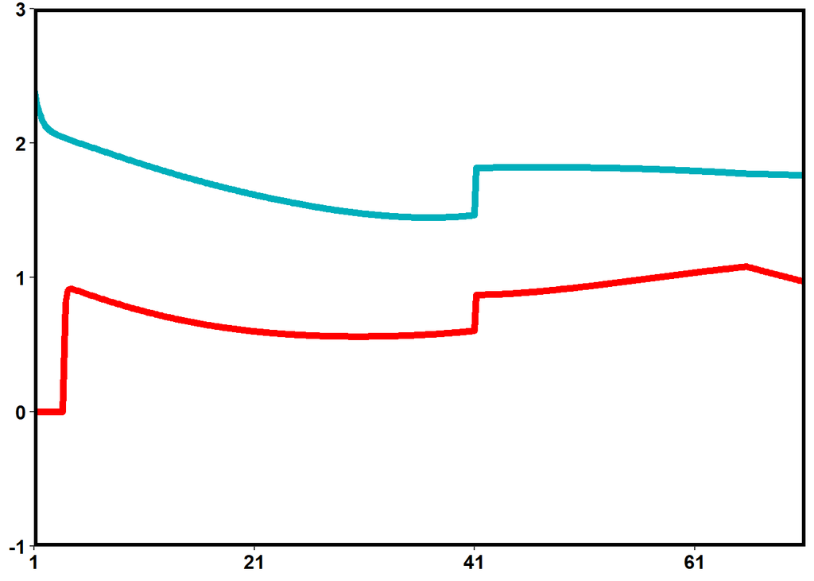

```r
##===================================================================
p1 <- ggplot() +
  geom_line (
      data = GL, aes(x = Time, y = CPlas_pup),
      colour = "red", lwd = 2, linetype = 1) +
  geom_line (data = GL, aes(x = Time, y = CPlas),
               colour = "#00AFBB", lwd = 2) +
  scale_x_continuous(breaks = seq(1, 71, 20),
                       limits = c(1, 71), expand=c(0,0)) +
  scale_y_continuous(expand=c(0,0),limits = c(-1, 3))

## Plot + theme
p1 <- p1 +
  theme (
    plot.background         = element_rect (fill="White"),
    text                    = element_text (family = "Times"),
    panel.border            = element_rect (colour = "black",
                                            fill=NA, size = 2),
    panel.background        = element_rect (fill="White"),
    panel.grid.major        = element_blank(),
    panel.grid.minor        = element_blank(),
    axis.text               = element_text (size   = 12,
                                            colour = "black",
                                            face = "bold"),
    axis.title              = element_blank(),
    legend.position='none')

p1 #Fig. 4a: Time-varying profiles of PFOS concentrations in maternal and fetal/neonatal plasma druing gestation/lactation
```

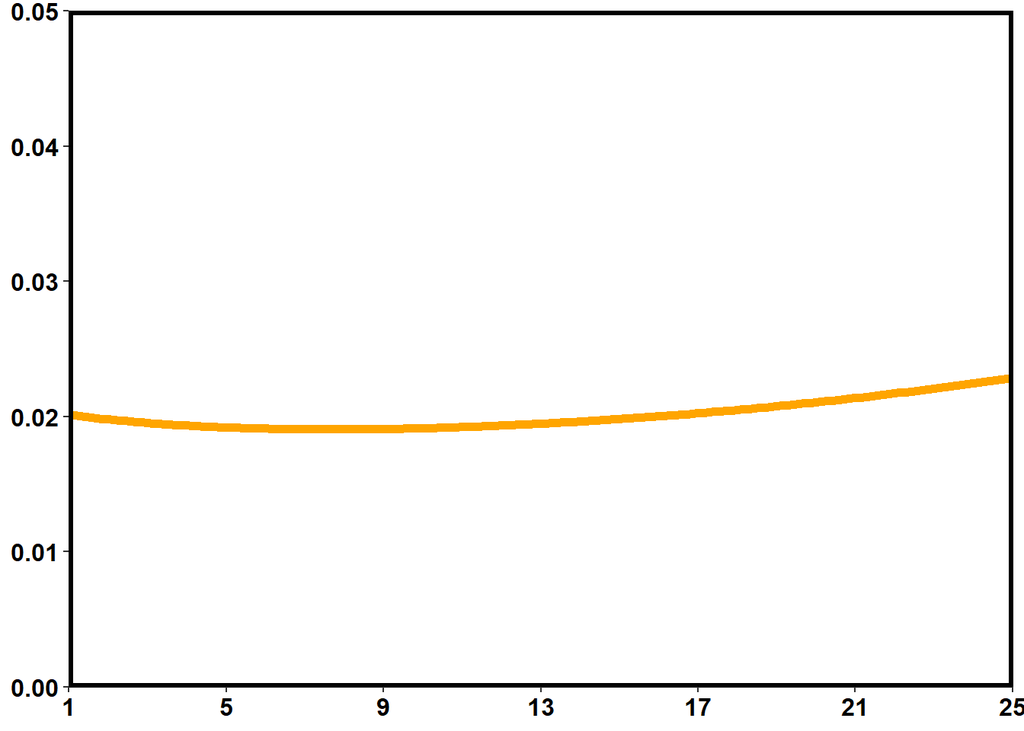

```r
##========================================================================
pmilk <- ggplot() +
  geom_line (data = LMilk, aes(x = (Time-40), y = CMilk), colour = "orange", lwd = 2, linetype = 1) +
  scale_x_continuous(breaks = seq(1, 25, 4), limits = c(1, 25), expand=c(0,0)) +
  scale_y_continuous(expand=c(0,0),limits = c(0, 0.05))

pmilk <- pmilk +
  theme (
    plot.background         = element_rect (fill="White"),
    text                    = element_text (family = "Times"),   # text front (Time new roman)
    panel.border            = element_rect (colour = "black", fill=NA, size=2),
    panel.background        = element_rect (fill="White"),
    panel.grid.major        = element_blank(),
    panel.grid.minor        = element_blank(),
    axis.text               = element_text (size   = 12,
                                            colour = "black",
                                            face = "bold"),
    axis.title              = element_blank(),
    legend.position='none')

pmilk ## Fig. 4b: Time-varying profiles of PFOS concentrations in milk druing lactation
```

# Save the figure

Save your figures using `ggsave()`. In the `ggsave` function, you should set up the your path to save your figure in the local drive.

```r
# ggsave("Fig.4a.tiff",scale = 1,
#        plot = p1,
#        path = "C:/Users/weichunc/Desktop",
#        width = 14, height = 9, units = "cm", dpi=320)
#
# ggsave("Fig.4b.tiff",scale = 1,
#        plot = pmilk,
#        path = "C:/Users/weichunc/Desktop",
#        width = 14, height = 9, units = "cm", dpi=320)
#
```